# Practical Machine Learning Project

## Packages Required

All packages required for the project are loaded below.

```r
library(caret)
library(rattle)
library(e1071)
```

## Reading in the Data

A training set CSV and a test set CSV are available. I shall use the test set CSV as my validation set and hold it out until the very end of the model-building. The training set CSV shall be split into a training set and a test set. The variables are named accordingly.

```r
trainingCSV<-read.csv(file=url("https://d396qusza40orc.cloudfront.net/predmachlearn/pml-training.csv"), header=TRUE)
validation<-read.csv(file=url("https://d396qusza40orc.cloudfront.net/predmachlearn/pml-testing.csv"), header=TRUE)
```

Explore the structure of both datasets.

```r
str(trainingCSV)
```

```
## 'data.frame':    19622 obs. of  160 variables:
##  $ X                       : int  1 2 3 4 5 6 7 8 9 10 ...
##  $ user_name               : chr  "carlitos" "carlitos" "carlitos" "carlitos" ...
##  $ raw_timestamp_part_1    : int  1323084231 1323084231 1323084231 1323084232 1323084232 1323084232 1323084232 1323084232 1323084232 1323084232 ...
##  $ raw_timestamp_part_2    : int  788290 808298 820366 120339 196328 304277 368296 440390 484323 484434 ...
##  $ cvtd_timestamp          : chr  "05/12/2011 11:23" "05/12/2011 11:23" "05/12/2011 11:23" "05/12/2011 11:23" ...
##  $ new_window              : chr  "no" "no" "no" "no" ...
##  $ num_window              : int  11 11 11 12 12 12 12 12 12 12 ...
##  $ roll_belt               : num  1.41 1.41 1.42 1.48 1.48 1.45 1.42 1.42 1.43 1.45 ...
##  $ pitch_belt              : num  8.07 8.07 8.07 8.05 8.07 8.06 8.09 8.13 8.16 8.17 ...
##  $ yaw_belt                : num  -94.4 -94.4 -94.4 -94.4 -94.4 -94.4 -94.4 -94.4 -94.4 -94.4 ...
##  $ total_accel_belt        : int  3 3 3 3 3 3 3 3 3 3 ...
##  $ kurtosis_roll_belt      : chr  "" "" "" "" ...
##  $ kurtosis_picth_belt     : chr  "" "" "" "" ...
##  $ kurtosis_yaw_belt       : chr  "" "" "" "" ...
```

[output cut: 86 more lines]

```r
str(validation)
```

```
## 'data.frame':    20 obs. of  160 variables:
##  $ X                       : int  1 2 3 4 5 6 7 8 9 10 ...
##  $ user_name               : chr  "pedro" "jeremy" "jeremy" "adelmo" ...
##  $ raw_timestamp_part_1    : int  1323095002 1322673067 1322673075 1322832789 1322489635 1322673149 1322673128 1322673076 1323084240 1322837822 ...
##  $ raw_timestamp_part_2    : int  868349 778725 342967 560311 814776 510661 766645 54671 916313 384285 ...
##  $ cvtd_timestamp          : chr  "05/12/2011 14:23" "30/11/2011 17:11" "30/11/2011 17:11" "02/12/2011 13:33" ...
##  $ new_window              : chr  "no" "no" "no" "no" ...
##  $ num_window              : int  74 431 439 194 235 504 485 440 323 664 ...
##  $ roll_belt               : num  123 1.02 0.87 125 1.35 -5.92 1.2 0.43 0.93 114 ...
##  $ pitch_belt              : num  27 4.87 1.82 -41.6 3.33 1.59 4.44 4.15 6.72 22.4 ...
##  $ yaw_belt                : num  -4.75 -88.9 -88.5 162 -88.6 -87.7 -87.3 -88.5 -93.7 -13.1 ...
##  $ total_accel_belt        : int  20 4 5 17 3 4 4 4 4 18 ...
##  $ kurtosis_roll_belt      : logi  NA NA NA NA NA NA ...
##  $ kurtosis_picth_belt     : logi  NA NA NA NA NA NA ...
##  $ kurtosis_yaw_belt       : logi  NA NA NA NA NA NA ...
```

[output cut: 86 more lines]

## Data Wrangling

The output from str() above shows that there are three categories of columns in the training set which are unnecessary variables and need to be removed before fitting a model.

- Firstly, there are some columns containing almost exclusively NA values.
- Secondly, the first 7 columns contain metadata which has no use for prediction.
- Thirdly, some columns may be vectors with a variance of almost zero.

The data wrangling procedure to remove all such columns is done below.

```r
# Remove columns which have at least 90 % missing values
trainingCSV<-trainingCSV[, colMeans(is.na(trainingCSV))<0.9]
```

```r
# Remove the first 7 columns, as they contain unnecessary metadata
trainingCSV<-trainingCSV[, -c(1:7)]
```

```r
# Remove variables with a near-zero variance
nzv<-nearZeroVar(x=trainingCSV)
trainingCSV<-trainingCSV[, -nzv]
```

Let us see how many columns we’re left with after wrangling.

```r
dim(trainingCSV)
```

```
## [1] 19622    53
```

Wrangling has taken us from 160 variables to 53 variables.

## Create Data Partitions

First, I split the training set CSV into a training set and a test set. The “classe” variable is the outcome variable.

```r
inTraining<-createDataPartition(y=trainingCSV$classe, p=0.75, list=FALSE)
training<-trainingCSV[inTraining, ]
test<-trainingCSV[-inTraining, ]
```

Secondly, I set up control for 5-fold cross-validation.

```r
control<-trainControl(method="cv", number=5)
```

## Decision Tree

The first model I will build is the decision tree. The model is trained on the training set below.

```r
treeModel<-train(classe~., data=training, method="rpart", trControl=control)
```

The summary of the fitted model is visualized by a fancy plot.

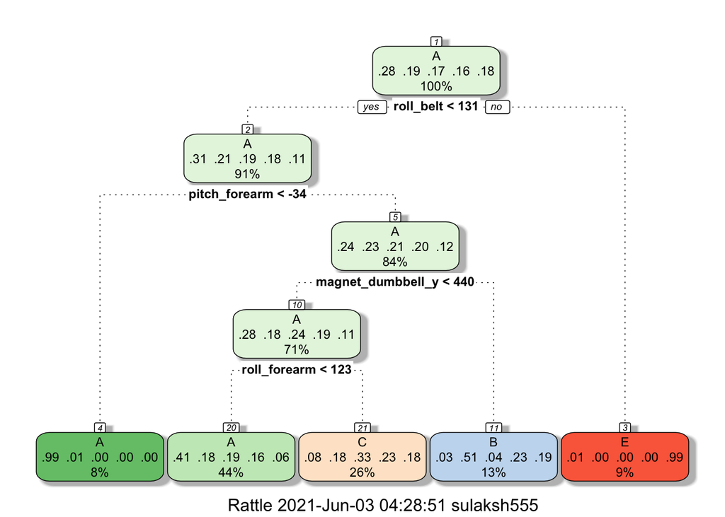

```r
fancyRpartPlot(model=treeModel$finalModel)
```

The cross-validation accuracy plot of the model is shown below.

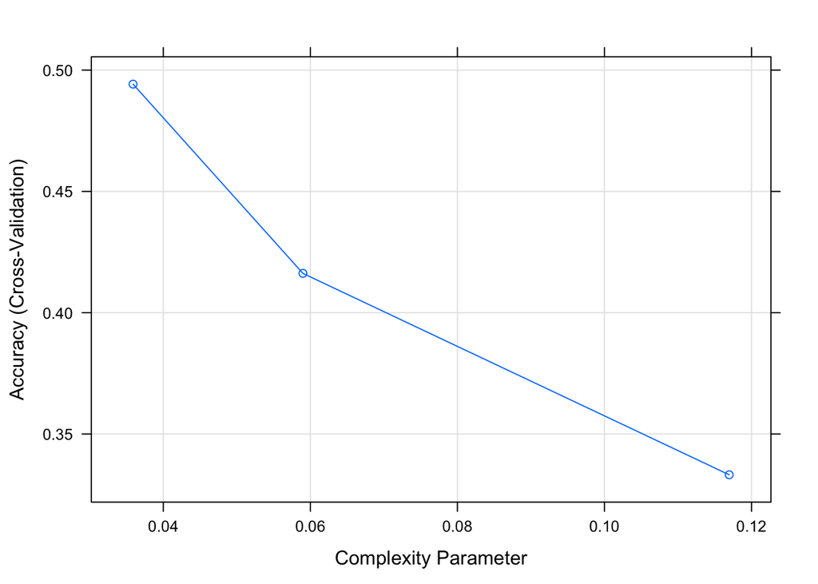

```r
plot(treeModel)
```

I now use the fitted model to make predictions on the test set and evaluate the accuracy of the predictions.

```r
predictTree<-predict(object=treeModel, newdata=test)
confMatTree<-confusionMatrix(data=predictTree, reference=factor(test$classe))

confMatTree
```

```
## Confusion Matrix and Statistics
##
##           Reference
## Prediction    A    B    C    D    E
##          A 1266  382  370  365  128
##          B   17  325   26  131  128
##          C  108  242  459  308  256
##          D    0    0    0    0    0
##          E    4    0    0    0  389
##
## Overall Statistics
##
##                Accuracy : 0.4973
##                  95% CI : (0.4833, 0.5114)
##     No Information Rate : 0.2845
##     P-Value [Acc > NIR] : < 2.2e-16
##
##                   Kappa : 0.3439
##
##  Mcnemar's Test P-Value : NA
##
## Statistics by Class:
##
##                      Class: A Class: B Class: C Class: D Class: E
## Sensitivity            0.9075  0.34247   0.5368   0.0000  0.43174
## Specificity            0.6452  0.92364   0.7743   1.0000  0.99900
## Pos Pred Value         0.5042  0.51834   0.3343      NaN  0.98982
## Neg Pred Value         0.9461  0.85410   0.8879   0.8361  0.88650
## Prevalence             0.2845  0.19352   0.1743   0.1639  0.18373
## Detection Rate         0.2582  0.06627   0.0936   0.0000  0.07932
## Detection Prevalence   0.5120  0.12785   0.2800   0.0000  0.08014
## Balanced Accuracy      0.7764  0.63305   0.6556   0.5000  0.71537
```

## Random Forest

```r
forestModel<-train(classe~., data=training, method="rf", trControl=control)
```

The cross-validation accuracy plot of the model is shown below.

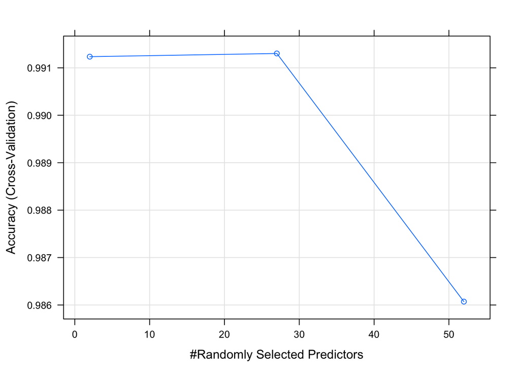

```r
plot(forestModel)
```

I now use the fitted model to make predictions on the test set and evaluate the accuracy of the predictions.

```r
predictForest<-predict(object=forestModel, newdata=test)
confMatForest<-confusionMatrix(data=predictForest, reference=factor(test$classe))

confMatForest
```

```
## Confusion Matrix and Statistics
##
##           Reference
## Prediction    A    B    C    D    E
##          A 1395    2    0    0    0
##          B    0  944    2    0    0
##          C    0    3  851    9    0
##          D    0    0    2  794    5
##          E    0    0    0    1  896
##
## Overall Statistics
##
##                Accuracy : 0.9951
##                  95% CI : (0.9927, 0.9969)
##     No Information Rate : 0.2845
##     P-Value [Acc > NIR] : < 2.2e-16
##
##                   Kappa : 0.9938
##
##  Mcnemar's Test P-Value : NA
##
## Statistics by Class:
##
##                      Class: A Class: B Class: C Class: D Class: E
## Sensitivity            1.0000   0.9947   0.9953   0.9876   0.9945
## Specificity            0.9994   0.9995   0.9970   0.9983   0.9998
## Pos Pred Value         0.9986   0.9979   0.9861   0.9913   0.9989
## Neg Pred Value         1.0000   0.9987   0.9990   0.9976   0.9988
## Prevalence             0.2845   0.1935   0.1743   0.1639   0.1837
## Detection Rate         0.2845   0.1925   0.1735   0.1619   0.1827
## Detection Prevalence   0.2849   0.1929   0.1760   0.1633   0.1829
## Balanced Accuracy      0.9997   0.9971   0.9962   0.9929   0.9971
```

## Predictions on the Validation Set

I’ve selected the random forest model as the best model to make predictions on the validation set, which I’ve been holding out all this while. These predictions are made below.

```r
predictValidation<-predict(object=forestModel, newdata=validation)

predictValidation
```

```
##  [1] B A B A A E D B A A B C B A E E A B B B
## Levels: A B C D E
```